# Introduction to MySQL

Kennedy Waweru

2/20/2022

## Lets create our first database

```sql
CREATE DATABASE IF NOT EXISTS manu_training;
```

We have successfully created database/schema using SQL command.

## Show databases

```sql
SHOW DATABASES;
```

7 records

| Database |
| --- |
| denaco_training |
| information_schema |
| manu_training |
| mysql |
| performance_schema |
| sample_db |
| sys |

Choose which database to use when evaluating commands

```sql
USE manu_training;
```

After selecting the database now we can query what tables are in the db

## Show Tables

```sql
SHOW TABLES;
```

2 records

| Tables_in_manu_training |
| --- |
| notified_births_census |
| persons |

## Create a Table

The CREATE TABLE statement allows you to create a new table in a database.

#### Syntax

```sql
CREATE TABLE table_name (
    column1 datatype,
    column2 datatype,
    column3 datatype,
   ....
);
```

First, you specify the name of the table that you want to create after the CREATE TABLE keywords. The table name must be unique within a database.

Second, you specify a list of columns of the table in the column_list section, columns are separated by commas.

### MySQL CREATE TABLE Example

The following example creates a table called “Persons” that contains five columns: PersonID, LastName, FirstName, Address, and City:

```sql
CREATE TABLE IF NOT EXISTS Persons (
    PersonID int,
    LastName varchar(255),
    FirstName varchar(255),
    Address varchar(255),
    City varchar(255)
);
```

The PersonID column is of type int and will hold an integer.

The LastName, FirstName, Address, and City columns are of type varchar and will hold characters, and the maximum length for these fields is 255 characters.

The empty “Persons” table will now look like this:

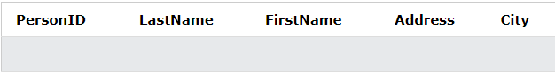

Persons Table

## See if table was created

```sql
SHOW TABLES;
```

2 records

| Tables_in_manu_training |
| --- |
| notified_births_census |
| persons |

## Describe a Table

We will use the **DESCRIBE** command to show the structure of our table, such as column names, constraints on column names, etc. The DESC command is a short form of the DESCRIBE command.

```sql
{DESCRIBE | DESC} table_name;
```

```sql
DESCRIBE persons;
```

5 records

| Field | Type | Null | Key | Default | Extra |
| --- | --- | --- | --- | --- | --- |
| PersonID | int | YES |  | NA |  |
| LastName | varchar(255) | YES |  | NA |  |
| FirstName | varchar(255) | YES |  | NA |  |
| Address | varchar(255) | YES |  | NA |  |
| City | varchar(255) | YES |  | NA |  |

The empty “Persons” table can now be filled with data with the **SQL INSERT INTO** statement.

## The MySQL INSERT INTO Statement

The **INSERT INTO** statement is used to insert new records in a table.

#### Syntax

It is good practice to specify both the column names and the values to be inserted:

```sql
INSERT INTO table_name (column1, column2, column3, ...)
VALUES (value1, value2, value3, ...);
```

If you are adding values for all the columns of the table, you do not need to specify the column names in the SQL query. However, make sure the order of the values is in the same order as the columns in the table.

```sql
INSERT INTO table_name
VALUES (value1, value2, value3, ...);
```

## INSERT INTO Example

```sql
INSERT INTO persons (LastName, FirstName, Address, City)
VALUES("Muller","Thomas","00100","Munich")
```

## MySQL INSERT multiple rows statement

Use a single MySQL INSERT statement to insert multiple rows into a table.

```sql
INSERT INTO table_name (column1, column2, column3, ...)
VALUES
    (value1, value2, value3, ...),
    (value1, value2, value3, ...),
    ...
    (value1, value2, value3, ...);
```

In the above syntax:

- First, specify the name of table that you want to insert after the INSERT INTO keywords.
- Second, specify a comma-separated column list inside parentheses after the table name.
- Third, specify a comma-separated list of row data in the VALUES clause. Each element of the list represents a row. The number of values in each element must be the same as the number of columns specified.

### Insert Multiple rows example

Lets insert 5 records into our persons table

```sql
INSERT INTO persons (PersonID, LastName, FirstName, Address, City)
VALUES(1,"Doe","Jane","0234","Nairobi"),
(2,"Einstein","Albert","1329", "Munich"),
(3,"Man","Bat","00001","New York"),
(4,"Margaret","Mitchelle","23344","Atlanta"),
(5,"Teresa","Mother","001324","Calcutta")
```

Lets see the number of rows our table contains

```sql
SELECT COUNT(*) FROM persons;
```

1 records

| COUNT(*) |
| --- |
| 6 |

## MySQL SELECT Statement

The SELECT statement is used to select data from a database.

The data returned is stored in a result table, called the result-set.

```sql
SELECT column1, column2, ...
FROM table_name;
```

Here, column1, column2, … are the field names of the table you want to select data from.

The SELECT and FROM are the keywords. By convention, you write the SQL keywords in uppercase. However, it’s not mandatory. Because SQL is case-insensitive, you can write the SQL statement in lowercase, uppercase, etc

If you want to select all the fields available in the table, use the “*” wildcard syntax:

```sql
SELECT * FROM persons;
```

## SELECT Columns Example

The following SQL statement selects the “LastName”, “FirstName” and “City” from “persons” table

```sql
SELECT
    LastName,
    FirstName,
    City
FROM
    persons;
```

6 records

| LastName | FirstName | City |
| --- | --- | --- |
| Doe | Jane | Kisumu |
| Einstein | Albert | Munich |
| Man | Bat | New York |
| Margaret | Mitchelle | Atlanta |
| Teresa | Mother | Calcutta |
| Muller | Thomas | Munich |

## Using the MySQL SELECT statement to retrieve data from all columns example

Use the __*__ wildcard

```sql
SELECT * FROM persons;
```

## The MySQL SELECT DISTINCT Statement

The SELECT DISTINCT statement is used to return only distinct (different) values.

Inside a table, a column often contains many duplicate values; and sometimes you only want to list the different (distinct) values.

#### Syntax

```sql
SELECT DISTINCT column1, column2, ...
FROM table_name;
```

### SELECT Example Without DISTINCT

```sql
SELECT City FROM persons;
```

6 records

| City |
| --- |
| Kisumu |
| Munich |
| New York |
| Atlanta |
| Calcutta |
| Munich |

#### SELECT DISTINCT Example

```sql
SELECT DISTINCT City from persons;
```

5 records

| City |
| --- |
| Kisumu |
| Munich |
| New York |
| Atlanta |
| Calcutta |

## CREATE a Sample Table

Let’s create a new table notified_births_census that records birth data for counties in Kenya.

```sql
CREATE TABLE notified_births_census(
    id INT NOT NULL AUTO_INCREMENT,
    county_name VARCHAR(155),
    total_births INT,
    notified_births INT,
    not_notified_births INT,
    dont_know INT,
    not_stated INT,
    percent_notified DECIMAL(5,2),
    PRIMARY KEY(id)
);
```

```sql
DESCRIBE notified_births_census;
```

8 records

| Field | Type | Null | Key | Default | Extra |
| --- | --- | --- | --- | --- | --- |
| id | int | NO | PRI | NA | auto_increment |
| county_name | varchar(155) | YES |  | NA |  |
| total_births | int | YES |  | NA |  |
| notified_births | int | YES |  | NA |  |
| not_notified_births | int | YES |  | NA |  |
| dont_know | int | YES |  | NA |  |
| not_stated | int | YES |  | NA |  |
| percent_notified | decimal(5,2) | YES |  | NA |  |

Let’s insert some records.

```sql
INSERT INTO notified_births_census (county_name, total_births, notified_births, not_notified_births, dont_know, not_stated, percent_notified)
 VALUES
('KENYA', 1340468, 1212142, 125714, 2609, 3, 90.4),
('RURAL', 888039, 777343, 108563, 2131, 2, 87.5),
('URBAN', 452429, 434799, 17151, 478, 1, 96.1),
('MOMBASA', 37249, 35201, 2026, 22, NULL, 94.5),
('KWALE', 29226, 26455, 2719, 52, NULL, 90.5),
('KILIFI', 44519, 41950, 2509, 60, NULL, 94.2),
('TANA RIVER', 11683, 8541, 3106, 36, NULL, 73.1),
('LAMU', 4235, 3909, 324, 2, NULL, 92.3),
('TAITA/TAVETA', 9110, 8674, 435, 1, NULL, 95.2),
('GARISSA', 16414, 12198, 3986, 230, NULL, 74.3),
('WAJIR', 16767, 10777, 5921, 69, NULL, 64.3),
('MANDERA', 26639, 17395, 9027, 217, NULL, 65.3),
('MARSABIT', 13679, 9971, 3679, 29, NULL, 72.9),
('ISIOLO', 8037, 6518, 1496, 23, NULL, 81.1),
('MERU', 38222, 36649, 1532, 41, NULL, 95.9),
('THARAKA-NITHI', 9109, 8681, 417, 11, NULL, 95.3),
('EMBU', 14556, 14206, 345, 5, NULL, 97.6),
('KITUI', 27650, 24459, 3115, 75, 1, 88.5),
('MACHAKOS', 33548, 31726, 1783, 39, NULL, 94.6),
('MAKUENI', 20805, 19462, 1294, 49, NULL, 93.5),
('NYANDARUA', 16247, 15825, 417, 4, 1, 97.4),
('NYERI', 16831, 16614, 204, 13, NULL, 98.7),
('KIRINYAGA', 13638, 13459, 175, 4, NULL, 98.7),
('MURANGA', 24866, 24332, 529, 5, NULL, 97.9),
('KIAMBU', 69596, 67736, 1818, 42, NULL, 97.3),
('TURKANA', 24758, 17782, 6726, 250, NULL, 71.8),
('WEST POKOT', 24511, 16956, 7441, 114, NULL, 69.2),
('SAMBURU', 10665, 7561, 3080, 24, NULL, 70.9),
('TRANS NZOIA', 29005, 24817, 4125, 63, NULL, 85.6),
('UASIN GISHU', 32983, 30932, 1995, 56, NULL, 93.8),
('ELGEYO/MARAKWET', 13212, 12459, 742, 11, NULL, 94.3),
('NANDI', 23603, 21137, 2414, 52, NULL, 89.6),
('BARINGO', 19697, 16061, 3567, 69, NULL, 81.5),
('LAIKIPIA', 15383, 13400, 1969, 14, NULL, 87.1),
('NAKURU', 64797, 59771, 4923, 102, 1, 92.2),
('NAROK', 40643, 32520, 7980, 143, NULL, 80.0),
('KAJIADO', 36244, 32319, 3833, 92, NULL, 89.2),
('KERICHO', 24383, 22344, 2007, 32, NULL, 91.6),
('BOMET', 24647, 22848, 1752, 47, NULL, 92.7),
('KAKAMEGA', 49974, 46136, 3774, 64, NULL, 92.3),
('VIHIGA', 14329, 13581, 733, 15, NULL, 94.8),
('BUNGOMA', 47722, 43706, 3936, 80, NULL, 91.6),
('BUSIA', 25597, 23344, 2222, 31, NULL, 91.2),
('SIAYA', 28260, 26784, 1433, 43, NULL, 94.8),
('KISUMU', 34078, 32296, 1752, 30, NULL, 94.8),
('HOMABAY', 34833, 31723, 3069, 41, NULL, 91.1),
('MIGORI', 37118, 33827, 3228, 63, NULL, 91.1),
('KISII', 32057, 30419, 1609, 29, NULL, 94.9),
('NYAMIRA', 14114, 13406, 696, 12, NULL, 95.0),
('NAIROBI CITY', 135229, 131275, 3851, 103, NULL, 97.1);
```

## Sorting Data

Now that we have some data in our table, let’s go ahead and sort it.

The **ORDER BY** keyword is used to sort the result-set in ascending or descending order.

The **ORDER BY** keyword sorts the records in ascending order by default. To sort the records in descending order, use the **DESC** keyword.

#### Syntax

```sql
SELECT column1, column2, ...
FROM table_name
ORDER BY column1 [ASC|DESC], column2 [ASC|DESC], ...;
```

When you use the **SELECT** statement to query data from a table, the order of rows in the result set is unspecified. To sort the rows in the result set, you add the **ORDER BY** clause to the **SELECT** statement.

### Using MySQL ORDER BY clause to sort the result set by one column example

#### Sort the counties by total number of births from county with lowest number of births

```sql
SELECT county_name, total_births
FROM notified_births_census
ORDER BY total_births;
```

Displaying records 1 - 10

| county_name | total_births |
| --- | --- |
| LAMU | 4235 |
| ISIOLO | 8037 |
| THARAKA-NITHI | 9109 |
| TAITA/TAVETA | 9110 |
| SAMBURU | 10665 |
| TANA RIVER | 11683 |
| ELGEYO/MARAKWET | 13212 |
| KIRINYAGA | 13638 |
| MARSABIT | 13679 |
| NYAMIRA | 14114 |

#### Sort the counties by total number of births starting with county with highest number of births

```sql
SELECT county_name, total_births
FROM notified_births_census
ORDER BY total_births DESC;
```

Displaying records 1 - 10

| county_name | total_births |
| --- | --- |
| KENYA | 1340468 |
| RURAL | 888039 |
| URBAN | 452429 |
| NAIROBI CITY | 135229 |
| KIAMBU | 69596 |
| NAKURU | 64797 |
| KAKAMEGA | 49974 |
| BUNGOMA | 47722 |
| KILIFI | 44519 |
| NAROK | 40643 |

We can also sort alphabetically

```sql
SELECT county_name, total_births
FROM notified_births_census
ORDER BY county_name
```

Displaying records 1 - 10

| county_name | total_births |
| --- | --- |
| BARINGO | 19697 |
| BOMET | 24647 |
| BUNGOMA | 47722 |
| BUSIA | 25597 |
| ELGEYO/MARAKWET | 13212 |
| EMBU | 14556 |
| GARISSA | 16414 |
| HOMABAY | 34833 |
| ISIOLO | 8037 |
| KAJIADO | 36244 |

## Filtering Data

### The SQL WHERE Clause

The WHERE clause is used to filter records.

It is used to extract only those records that fulfill a specified condition.

#### Syntax

```sql
SELECT column1, column2, ...
FROM table_name
WHERE condition;
```

## WHERE Clause Example

SHOW total_births for county_name NAIROBI

```sql
SELECT county_name, total_births FROM notified_births_census WHERE county_name = "NAIROBI CITY";
```

1 records

| county_name | total_births |
| --- | --- |
| NAIROBI CITY | 135229 |

### Text Fields vs. Numeric Fields

SQL requires single quotes around text values (most database systems will also allow double quotes).

However, numeric fields should not be enclosed in quotes:

#### Example

```sql
SELECT county_name, total_births FROM notified_births_census WHERE not_stated = 1;
```

4 records

| county_name | total_births |
| --- | --- |
| URBAN | 452429 |
| KITUI | 27650 |
| NYANDARUA | 16247 |
| NAKURU | 64797 |

## Population density by subcounty in kenya Data

Load in the data provided in the [population_density_county_subcounty.sql](https://github.com/KennedyWaweru/ManuDataScience) Github repo.

Make sure the records are inserted correctly into your table.

We will proceed to use this table to learn more about the **WHERE** clause

### Operators in The WHERE Clause

The following operators can be used in the **WHERE** clause

#### Equal =

Select the sub counties that have 12 square kilometers

```sql
SELECT county_name, subcounty_name,square_kms
FROM subcounty_population_density
WHERE square_kms = 12;
```

2 records

| county_name | subcounty_name | square_kms |
| --- | --- | --- |
| Nairobi | KIBRA | 12 |
| Nairobi | MAKADARA | 12 |

#### Greater Than >

Select all the sub counties which have more than 500,000 total population

```sql
SELECT county_name, subcounty_name, total
FROM subcounty_population_density
WHERE total > 500000;
```

3 records

| county_name | subcounty_name | total |
| --- | --- | --- |
| Nairobi | EMBAKASI | 988808 |
| Nairobi | KASARANI | 780656 |
| Nairobi | NJIRU | 626482 |

#### less Than <

Select all counties which have less than 10,000 total population

```sql
SELECT county_name, subcounty_name, total
FROM subcounty_population_density
WHERE total < 10000;
```

Displaying records 1 - 10

| county_name | subcounty_name | total |
| --- | --- | --- |
| Meru | MERU NATIONAL PARK | 385 |
| Meru | MT. KENYA FOREST | 463 |
| Tharaka Nithi | MOUNT KENYA FOREST | 398 |
| Embu | MOUNT KENYA FOREST | 22 |
| Nyandarua | ABERDARE NATIONAL PARK | 15 |
| Nyeri | MT. KENYA FOREST | 188 |
| Nyeri | ABERDARE FOREST | 106 |
| Kirinyaga | MOUNT KENYA FOREST | 70 |
| Murang’a | ABERDARE FOREST | 43 |
| Narok | MAU FOREST | 32 |

#### <= less than or equal to

```sql
SELECT county_name, subcounty_name, total
FROM subcounty_population_density
WHERE square_kms < 12;
```

2 records

| county_name | subcounty_name | total |
| --- | --- | --- |
| Nairobi | KAMUKUNJI | 268276 |
| Nairobi | MATHARE | 206564 |

Inclusive

```sql
SELECT county_name, subcounty_name, total
FROM subcounty_population_density
WHERE square_kms <= 12;
```

4 records

| county_name | subcounty_name | total |
| --- | --- | --- |
| Nairobi | KAMUKUNJI | 268276 |
| Nairobi | KIBRA | 185777 |
| Nairobi | MAKADARA | 189536 |
| Nairobi | MATHARE | 206564 |

#### <> Not equal

**Note**: In some versions of SQL this operator may be written as **!=**

```sql
SELECT county_name, subcounty_name
FROM subcounty_population_density
WHERE county_name <> 'Nairobi';
```

Displaying records 1 - 10

| county_name | subcounty_name |
| --- | --- |
| Mombasa | CHANGAMWE |
| Mombasa | JOMVU |
| Mombasa | KISAUNI |
| Mombasa | LIKONI |
| Mombasa | MVITA |
| Mombasa | NYALI |
| Kwale | KINANGO |
| Kwale | LUNGA LUNGA |
| Kwale | MATUGA |
| Kwale | MSAMBWENI |

## The SQL AND, OR and NOT Operators

The **WHERE** clause can be combined with **AND**, **OR**, and **NOT** operators.

The **AND** and **OR** operators are used to filter records based on more than one condition

- The **AND** operator displays a record if all the conditions separated by **AND** are **TRUE**.
- The **OR** operator displays a record if any of the conditions separated by **OR** is **TRUE**.

The **NOT** operator displays a record if the condition(s) is **NOT TRUE**.

### AND

##### Syntax

```sql
SELECT column1, column2, ...
FROM table_name
WHERE condition1 AND condition2 AND condition3 ...;
```

#### Example

Select sub counties in nairobi county which have less than 200000 total population

```sql
SELECT county_name, subcounty_name, total
FROM subcounty_population_density
WHERE county_name = 'Nairobi' AND total < 200000;
```

3 records

| county_name | subcounty_name | total |
| --- | --- | --- |
| Nairobi | KIBRA | 185777 |
| Nairobi | LANG’ATA | 197489 |
| Nairobi | MAKADARA | 189536 |

### OR

#### Syntax

```sql
SELECT column1, column2, ...
FROM table_name
WHERE condition1 OR condition2 OR condition3 ...;
```

#### Example

The following SQL statement selects all fields from “subcounty_population_density” where county_name is “Nairobi” or “Mombasa”

```sql
SELECT county_name, subcounty_name
FROM subcounty_population_density
WHERE county_name = 'Nairobi' OR county_name = 'Mombasa';
```

Displaying records 1 - 10

| county_name | subcounty_name |
| --- | --- |
| Mombasa | CHANGAMWE |
| Mombasa | JOMVU |
| Mombasa | KISAUNI |
| Mombasa | LIKONI |
| Mombasa | MVITA |
| Mombasa | NYALI |
| Nairobi | DAGORETTI |
| Nairobi | EMBAKASI |
| Nairobi | KAMUKUNJI |
| Nairobi | KASARANI |

### NOT

#### Syntax

```sql
SELECT column1, column2, ...
FROM table_name
WHERE NOT condition;
```

#### Example

The following SQL statement selects all fields from “subcounty_population_density” where the county_name is not Nairobi

```sql
SELECT county_name, subcounty_name, total
FROM subcounty_population_density
WHERE NOT county_name='Nairobi';
```

Displaying records 1 - 10

| county_name | subcounty_name | total |
| --- | --- | --- |
| Mombasa | CHANGAMWE | 131882 |
| Mombasa | JOMVU | 163415 |
| Mombasa | KISAUNI | 291930 |
| Mombasa | LIKONI | 250358 |
| Mombasa | MVITA | 154171 |
| Mombasa | NYALI | 216577 |
| Kwale | KINANGO | 94220 |
| Kwale | LUNGA LUNGA | 198423 |
| Kwale | MATUGA | 194252 |
| Kwale | MSAMBWENI | 177690 |

### Combining AND, OR and NOT

You can also combine the AND, OR and NOT operators.

The following statement selects all fields from subcounty_population_density that are in Nairobi or Mombasa county which have a population density of more than 10000

```sql
SELECT county_name, subcounty_name, total, pop_density
FROM subcounty_population_density
WHERE (county_name = 'Nairobi' OR county_name = 'Mombasa') AND pop_density > 10000;
```

8 records

| county_name | subcounty_name | total | pop_density |
| --- | --- | --- | --- |
| Mombasa | MVITA | 154171 | 10543 |
| Nairobi | DAGORETTI | 434208 | 14908 |
| Nairobi | EMBAKASI | 988808 | 11460 |
| Nairobi | KAMUKUNJI | 268276 | 25455 |
| Nairobi | KIBRA | 185777 | 15311 |
| Nairobi | MAKADARA | 189536 | 16150 |
| Nairobi | MATHARE | 206564 | 68940 |
| Nairobi | STAREHE | 210423 | 10205 |

### BETWEEN

MySQL **BETWEEN** operator to determine whether a value is in a range of values.

#### Syntax

```sql
SELECT column1, column2, ...
FROM table_name
WHERE value BETWEEN low AND high;
```

Select all the fields where subcounty square_kms are within the range 1000 and 10000

```sql
SELECT county_name, subcounty_name, square_kms
FROM subcounty_population_density
WHERE square_kms BETWEEN 1000 AND 10000;
```

Displaying records 1 - 10

| county_name | subcounty_name | square_kms |
| --- | --- | --- |
| Kwale | KINANGO | 1612 |
| Kwale | LUNGA LUNGA | 2765 |
| Kwale | MATUGA | 1034 |
| Kwale | SAMBURU | 2430 |
| Kilifi | GANZE | 3218 |
| Kilifi | MAGARINI | 5229 |
| Kilifi | MALINDI | 2263 |
| Tana River | TANA RIVER | 9167 |
| Lamu | LAMU EAST | 2338 |
| Lamu | LAMU WEST | 3945 |

#### IN

The IN operator allows you to determine if a value matches any value in a list of values.

#### Syntax

```sql
SELECT column1, column2, ...
FROM table_name
WHERE value IN (value1, value2, value3,...)
```

#### Example

```sql
SELECT 1 IN (1,2,3);
```

1 records

| 1 IN (1,2,3) |
| --- |
| 1 |

# Select all fields where the counties are in the list of Kenyan cities

```sql
SELECT county_name, subcounty_name, total
FROM subcounty_population_density
WHERE county_name IN ('Nairobi','Mombasa','Kisumu','Nakuru');
```

Displaying records 1 - 10

| county_name | subcounty_name | total |
| --- | --- | --- |
| Mombasa | CHANGAMWE | 131882 |
| Mombasa | JOMVU | 163415 |
| Mombasa | KISAUNI | 291930 |
| Mombasa | LIKONI | 250358 |
| Mombasa | MVITA | 154171 |
| Mombasa | NYALI | 216577 |
| Nakuru | GILGIL | 185209 |
| Nakuru | KURESOI NORTH | 175074 |
| Nakuru | KURESOI SOUTH | 155324 |
| Nakuru | MOLO | 156732 |

#### IS NULL

Show the number rows that are missing/NULL values for square_kms column

```sql
SELECT county_name, subcounty_name, square_kms
FROM subcounty_population_density
WHERE square_kms IS NULL;
```

1 records

| county_name | subcounty_name | square_kms |
| --- | --- | --- |
| Kericho | TINDERET FOREST | NA |

**Note**: **IS NULL** is different from = 0

```sql
SELECT county_name, subcounty_name, square_kms
FROM subcounty_population_density
WHERE square_kms = 0;
```

0 records

| county_name | subcounty_name | square_kms |
| --- | --- | --- |

**Note**: comparing any value to NULL will always return False

> NULL = NULL Returns False

Show all fields where pop_density are missing values

```sql
SELECT county_name, subcounty_name, total, pop_density
FROM subcounty_population_density
WHERE pop_density IS NULL;
```

Displaying records 1 - 10

| county_name | subcounty_name | total | pop_density |
| --- | --- | --- | --- |
| Meru | MERU NATIONAL PARK | 385 | NA |
| Meru | MT. KENYA FOREST | 463 | NA |
| Embu | MOUNT KENYA FOREST | 22 | NA |
| Nyandarua | ABERDARE NATIONAL PARK | 15 | NA |
| Nyeri | MT. KENYA FOREST | 188 | NA |
| Nyeri | ABERDARE FOREST | 106 | NA |
| Kirinyaga | MOUNT KENYA FOREST | 70 | NA |
| Murang’a | ABERDARE FOREST | 43 | NA |
| Baringo | LAKE BARINGO | NA | NA |
| Narok | MAU FOREST | 32 | NA |

### LIKE and Wildcards

```sql
SELECT county_name, subcounty_name
FROM subcounty_population_density
WHERE county_name LIKE "N%";
```

Displaying records 1 - 10

| county_name | subcounty_name |
| --- | --- |
| Nyandarua | KINANGOP |
| Nyandarua | NYANDARUASOUTH |
| Nyandarua | MIRANGINE |
| Nyandarua | KIPIPIRI |
| Nyandarua | NYANDARUACENTRAL |
| Nyandarua | NYANDARUAWEST |
| Nyandarua | NYANDARUANORTH |
| Nyandarua | ABERDARE NATIONAL PARK |
| Nyeri | TETU |
| Nyeri | KIENI EAST |